# Анализ убытков приложения ProcrastinatePRO+

Таким образом, можно предположить, что пользователи не окупаются по причине черезчур разросшегося рекламного бюджета и неэффективности рекламных источников привлечения. Чтобы убедиться что дело именно в этом, а не в чем-либо другом, важно проанализировать все доступные характеристики пользователей, и в особенности каналы привлечения.

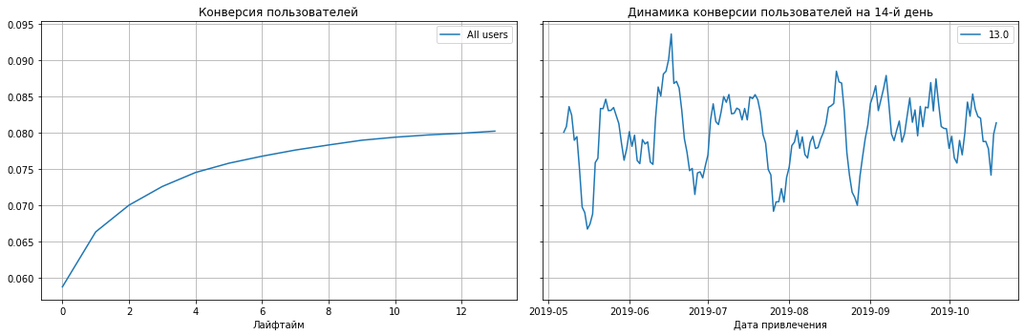

```python
# смотрим конверсию

conversion_raw, conversion_grouped, conversion_history = get_conversion(
    profiles, orders, observation_date, horizon_days
)

plot_conversion(conversion_grouped, conversion_history, horizon_days)
```

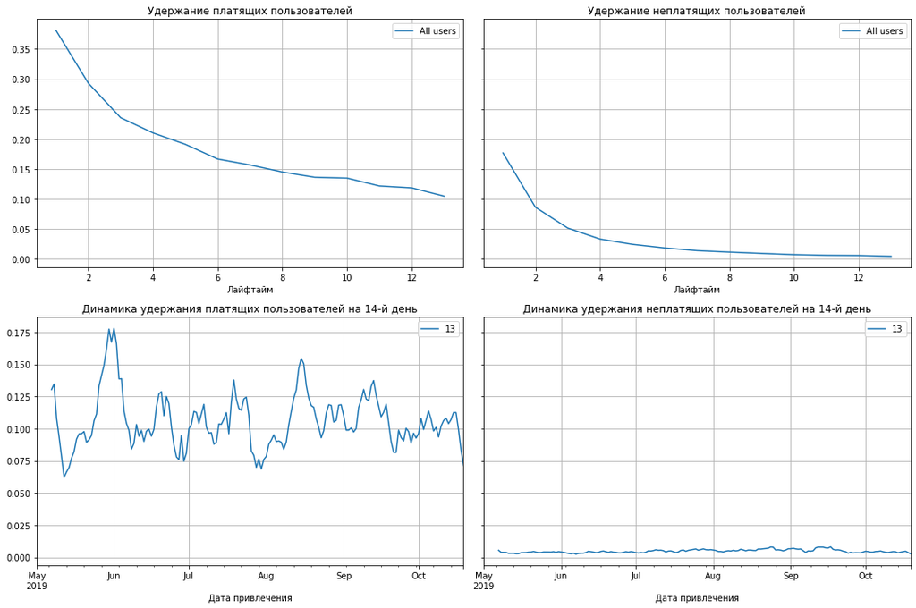

```python
# смотрим удержание

retention_raw, retention_grouped, retention_history = get_retention(
    profiles, visits, observation_date, horizon_days
)

plot_retention(retention_grouped, retention_history, horizon_days)
```

Графики удержания не вызывают вопросов, выглядят стабильно и ожидаемо.

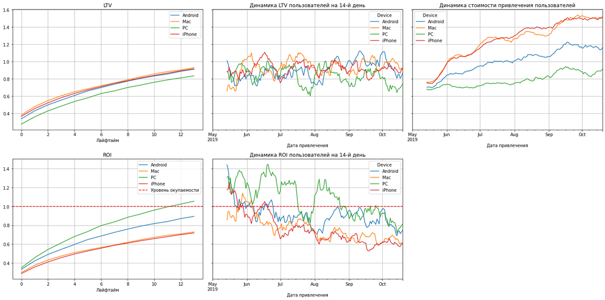

```python
# смотрим окупаемость с разбивкой по устройствам

dimensions = ['Device']

ltv_raw, ltv_grouped, ltv_history, roi_grouped, roi_history = get_ltv(
    profiles, orders, observation_date, horizon_days, dimensions=dimensions
)

plot_ltv_roi(
    ltv_grouped, ltv_history, roi_grouped, roi_history, horizon_days, window=14
)
```

Стоимость привлечения пользователей яблочных устройств значительно выше чем других платформ. Окупаются только пользователи ПК, и стоимость привлечения самая низкая.

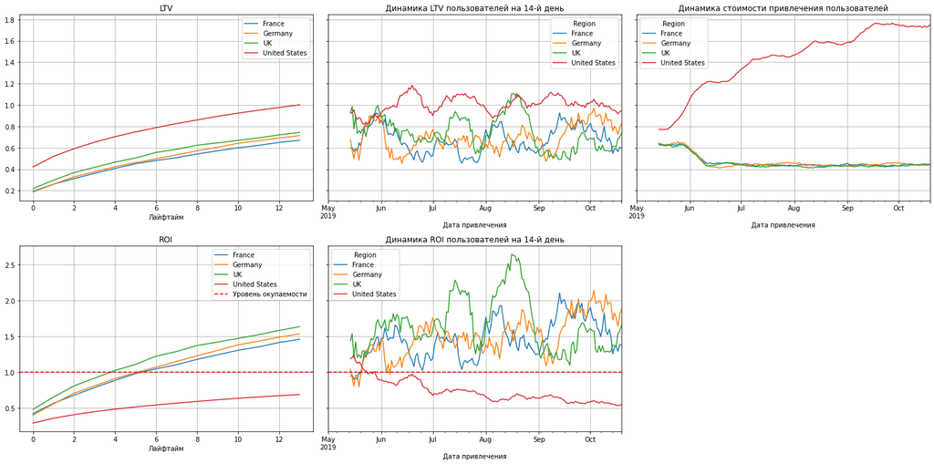

```python
# смотрим окупаемость с разбивкой по странам

dimensions = ['Region']

ltv_raw, ltv_grouped, ltv_history, roi_grouped, roi_history = get_ltv(
    profiles, orders, observation_date, horizon_days, dimensions=dimensions
)

plot_ltv_roi(
    ltv_grouped, ltv_history, roi_grouped, roi_history, horizon_days, window=14
)
```

Пользователи из США приносят денег больше чем пользователи из других стран, но затраты на их привлечение в разы больше и поэтмоу они единственные не окупаются. Это также подтверждает то, что график динамики окупаемости зеркально повторяет график стоимости привлечения.

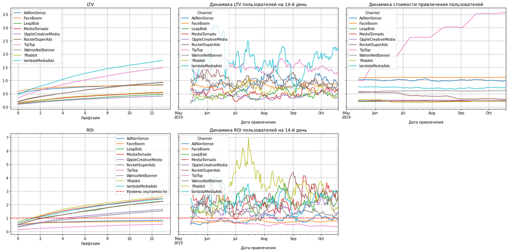

|  | Channel | unique users | payers | % of payers |
| --- | --- | --- | --- | --- |
| 0 | FaceBoom | 29144 | 3557 | 12.2 |
| 1 | AdNonSense | 3880 | 440 | 11.3 |
| 2 | lambdaMediaAds | 2149 | 225 | 10.5 |
| 3 | TipTop | 19561 | 1878 | 9.6 |
| 4 | RocketSuperAds | 4448 | 352 | 7.9 |
| 5 | WahooNetBanner | 8553 | 453 | 5.3 |
| 6 | YRabbit | 4312 | 165 | 3.8 |
| 7 | MediaTornado | 4364 | 156 | 3.6 |
| 8 | LeapBob | 8553 | 262 | 3.1 |
| 9 | OppleCreativeMedia | 8605 | 233 | 2.7 |

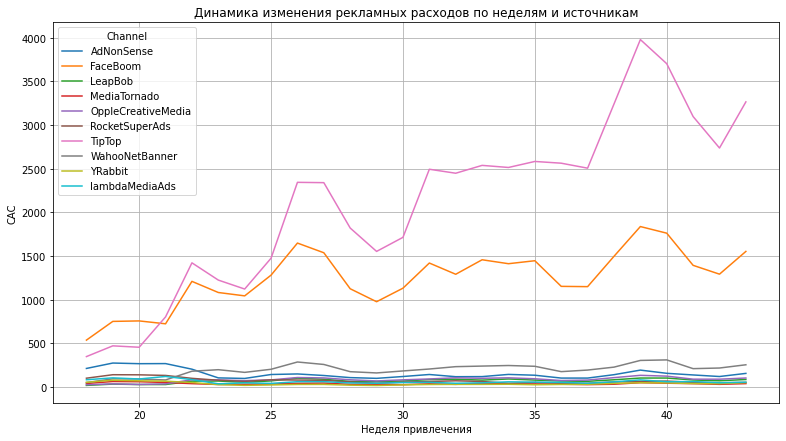

```python
# смотрим окупаемость с разбивкой по источникам привлечения

dimensions = ['Channel']

ltv_raw, ltv_grouped, ltv_history, roi_grouped, roi_history = get_ltv(
    profiles, orders, observation_date, horizon_days, dimensions=dimensions
)

plot_ltv_roi(
    ltv_grouped, ltv_history, roi_grouped, roi_history, horizon_days, window=14
)

pivot_week_costs=costs.pivot_table(index='week', columns='Channel', values='costs', aggfunc='sum')
pivot_week_costs.plot(grid=True,figsize=(13,7),title='Динамика изменения рекламных расходов по неделям и источникам')
plt.ylabel('CAC')
plt.xlabel('Неделя привлечения')
plt.show

payers_per_channel = (
        profiles.groupby('Channel')
        .agg({'User Id': 'nunique','payer':'sum'})
        .rename(columns={'User Id': 'unique users','payer':'payers'})
        .reset_index()
    )
payers_per_channel['% of payers'] = ((payers_per_channel['payers'] / payers_per_channel['unique users']) * 100).round(1)
display(payers_per_channel.sort_values(by='% of payers',ascending=False).reset_index(drop=True))
```

Все остальные рекламные источники имеют слабый LTV но из-за небольших рекламных бюджетов и низкой стоимости привлечения одного пользователя они всеже приносят прибыль.\ Исключение составляет lambdaMediaAds - несмотря на очень небольшой бюджет среди его пользователей очень большой процент платящих и самый высокий LTV, стоимость привлечения одного пользователя выше чем у других, но не сильно, из-за чего его показатели очень хороши.

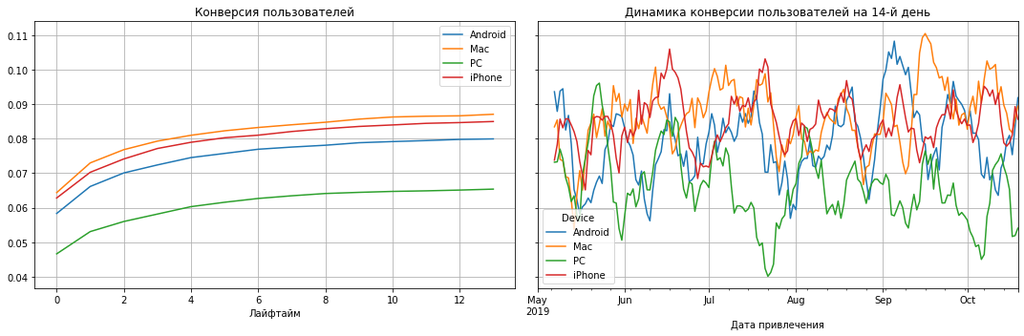

```python
# смотрим конверсию с разбивкой по устройствам

dimensions = ['Device']

conversion_raw, conversion_grouped, conversion_history = get_conversion(
    profiles, orders, observation_date, horizon_days, dimensions=dimensions
)

plot_conversion(conversion_grouped, conversion_history, horizon_days)
```

Динамика конврссии у всех стабильна а вот конверсия и пользователей ПК самая низкая.

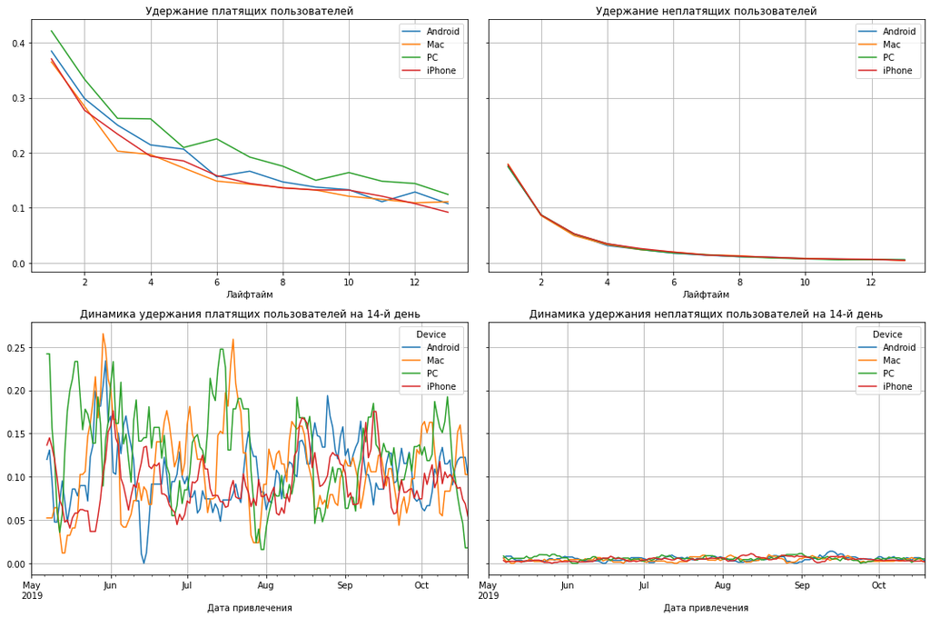

```python
# смотрим удержание с разбивкой по устройствам

retention_raw, retention_grouped, retention_history = get_retention(
    profiles, visits, observation_date, horizon_days, dimensions=dimensions
)

plot_retention(retention_grouped, retention_history, horizon_days)
```

Пользователи ПК удерживаются немного лучше остальных.

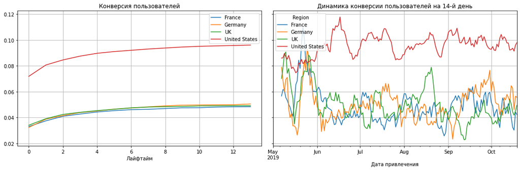

```python
# смотрим конверсию с разбивкой по регионам

dimensions = ['Region']

conversion_raw, conversion_grouped, conversion_history = get_conversion(
    profiles, orders, observation_date, horizon_days, dimensions=dimensions
)

plot_conversion(conversion_grouped, conversion_history, horizon_days)
```

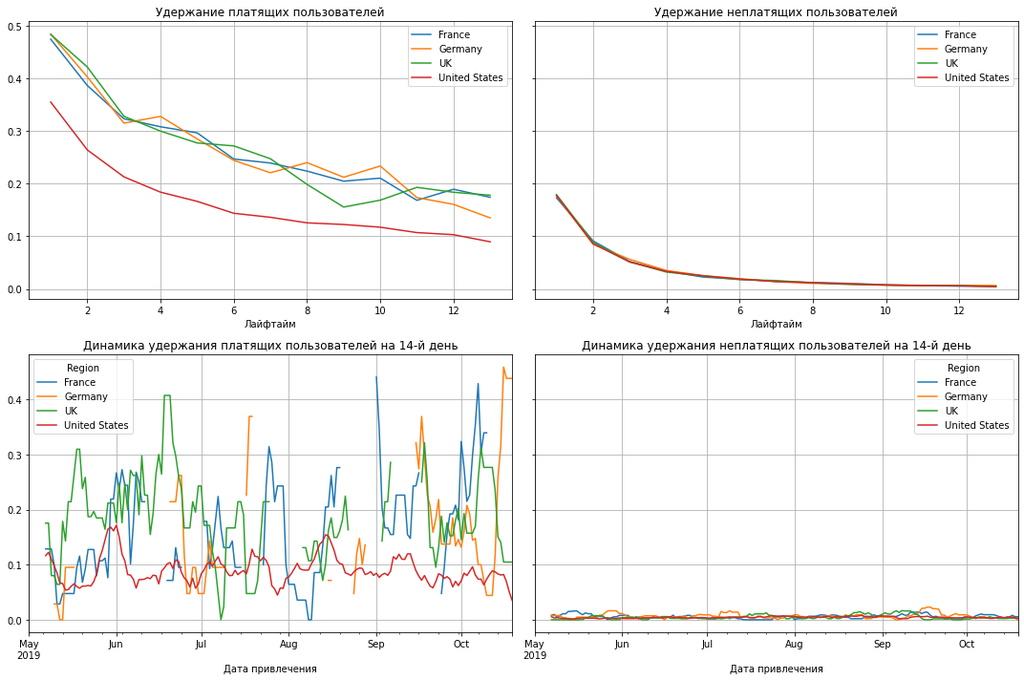

```python
# смотрим удержание с разбивкой по регионам

retention_raw, retention_grouped, retention_history = get_retention(
    profiles, visits, observation_date, horizon_days, dimensions=dimensions
)

plot_retention(retention_grouped, retention_history, horizon_days)
```

Интересно, пользователи из США намного чаще конвенртируются в платящих пользователей, но их удержание показывает противоположную картину.

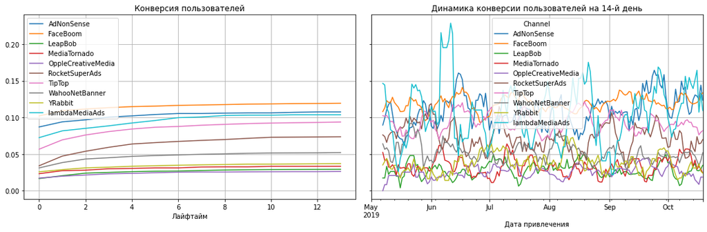

```python
# смотрим конверсию с разбивкой по каналам привлечения

dimensions = ['Channel']

conversion_raw, conversion_grouped, conversion_history = get_conversion(
    profiles, orders, observation_date, horizon_days, dimensions=dimensions
)

plot_conversion(conversion_grouped, conversion_history, horizon_days)
```

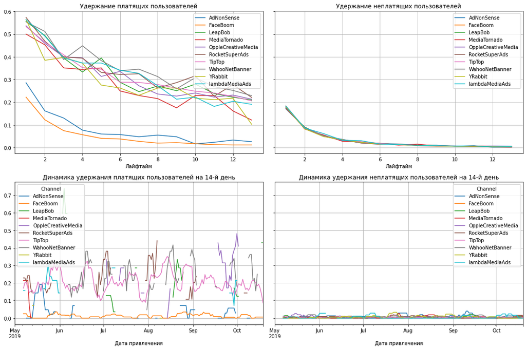

```python
# смотрим удержание с разбивкой по каналам привлечения

retention_raw, retention_grouped, retention_history = get_retention(
    profiles, visits, observation_date, horizon_days, dimensions=dimensions
)

plot_retention(retention_grouped, retention_history, horizon_days)
```

Ситуация с FaceBoom и ADNonSense аналогична ситуации с США - высокая конверсия но низкое удержание

**Окупается ли реклама, направленная на привлечение пользователей в целом?**\ Нет, реклама не окупается.

**Какие устройства, страны и рекламные каналы могут оказывать негативное влияние на окупаемость рекламы?**\ Яблочные устроиства, США и самые высокобюджетные каналы оказывают наибольшее негативное влияние на оккупаемость.

**Чем могут быть вызваны проблемы окупаемости?**

- Завышенные бюджеты на рекламу.
- Неправильное распределение рекламных бюджетов по источникам и рынкам.
- Неподходящий выбор способа оплаты рекламы.

### Выводы

**Причины неэффективности привлечения:**

Возможные причины плохой окупаемости рекламы:

- Слишком высокая стоимость привлечения пользователей из США при очень плохом их удержании.
- Высокая стоимость привлечение и плохое удержание у пользователей всех девайсов кроме ПК.
- FaceBoom привлекает больше всего платящих пользоватей и у него лучшая конверсия но из-за раздтых рекламных бюджетов, высокой стоимости привлечения и плохого удержания он не окупается
- AdNonSense ситауция аналогична FaceBoom
- TipTopимеет хорошие показатели по всем параметрам но его пользователи не окуаются из-за слишком высокой стоимости привлечения, она более чем в 2 раза выше чем у близжайших конкукрентов!
- lambdaMediaAds Отличный LTV, конверсия и неплохие иные показатели, но стоимость привлечения хоть и не самая но высокая, поэтому он окупается но не так хорошо как мог бы.
- Rocket super ads средний по всем показателям но имеет очень высокое удержание, из-за чего хорошо окупается.
- Анализ хорошо окупающихся источников показывает, что низкая стоимость привлечения и высокий уровень удержания влияют на окупаемость сильнее, чем конверсия и LTV.

**Рекомендации для отдела маркетинга:**

- Уделить больше внимания продвижению и рекламе на других рынках и платформах а не только США.
- При выборе рекламных источников "не класть все яица в одну корзину" и распределять бюджет равномернее между источниками и ограничивать в дальнейшем количество денег выделяемых на один рекламный источник.
- Выбирать источники рекламы с меньшей ценой привлечения клиента (желательно менее 0.5 за клиента), попробовать использовать другие системы оплаты рекламы, направлять рекламу на другую, более платежеспособную аудиторию, уделять больше внимания удержанию пользователей.
- Направить больше усилий на привлечение Немецких пользователей, у них хорошие перспективы.
- Обратить внимание на перспективные источники привлечения пользователей YRabbit, LeapBob, lambdaMediaAds, MediaTornado.
- Сделать запрос в отдел разработки MAC и IOS устроиств о проверке их приложений на баги и проблемы с оплатой.

В начало